# Stream Flux

Andrew

10/29/2019

## Import data

In this document we are going to calculate Evasion from the Vaisala Sensors and compare them to the eosFD flux measurements as well as see how they relate to other variables such as precipitation and temperature. First we import the data and for now we will filter so we are looking at non-injections

# Create new time variables for ease of plotting

These new variables will help us plot each seperate day on a timescale of midnight -> midnight

```r
df$day <- as.factor(substr(as.character(df$DateTime),1,10))
times <- substr(as.character(df$DateTime),12,16)
df$time <- strftime(df$DateTime, format="%H:%M")
df$time <- as.POSIXct(df$time, format="%H:%M")
```

## Change in CO2 Station 1->4

Let’s visualize the changes in diel CO2 concentrations between a pair of sensors. Here we look at the entire reach, so stations 1 -> 4. We have a filter to remove some data that had issues.

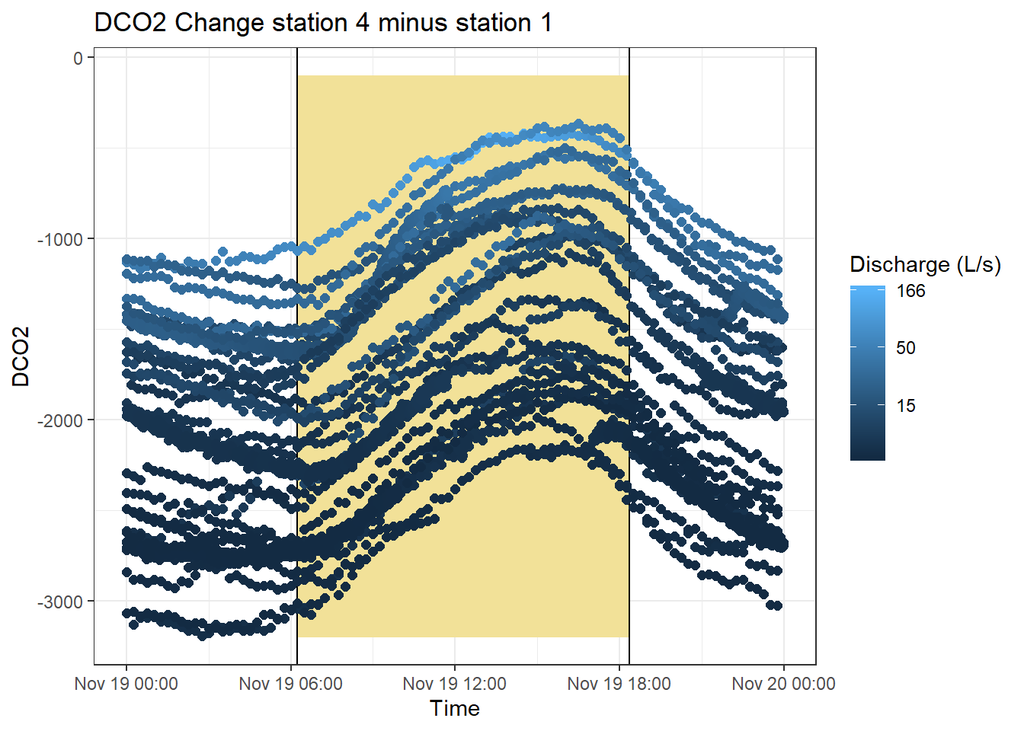

```r
filt <- df%>%
  filter(!is.na(V1)&!is.na(V4))%>%
  filter(DateTime > as.POSIXct("2019-07-13 00:00:00"))%>%
  filter(DateTime < as.POSIXct("2019-08-13 19:00:00")|DateTime > as.POSIXct("2019-08-14 23:59"))%>%
  filter(DateTime < as.POSIXct("2019-07-14 00:00")|DateTime > as.POSIXct("2019-07-14 23:59"))%>%
  filter(!DateTime == as.POSIXct("2019-08-09 09:57:00"))


dayPoly <- data.frame(x = c(as.POSIXct("06:15", format = "%H:%M"),as.POSIXct("18:21", format = "%H:%M"),as.POSIXct("18:21", format = "%H:%M"),as.POSIXct("06:15", format = "%H:%M")),y=c(-3200,-3200,-100,-100))

my_breaks <- c(0,15,50,166) # Create breaks

plot14Ppm <- ggplot(filt)+
  geom_polygon(data = dayPoly,aes(x=x,y=y),fill="#f2e198")+
  geom_vline(aes(xintercept = as.POSIXct("06:15", format = "%H:%M")))+
  geom_vline(aes(xintercept = as.POSIXct("18:21", format = "%H:%M")))+
  geom_point(aes(x = time, y = V4-V1,group = day, col=stn1_Q),lwd=2)+
  scale_color_gradient(name = "Discharge (L/s)", trans = "log",
                        breaks = my_breaks, labels = my_breaks)+
  labs(x = "Time",y="DCO2", title = "DCO2 Change station 4 minus station 1")+
  theme_bw()

plot14Ppm
```

So now that we know what the change in CO2 between stations, it’s time to account for stream metabolism. Metabolism can be determined by taking the change in CO2 between stations before sunrise (photosynthesis is zero) and subtracting it from the change in CO2 at all other times. Let’s try to confirm this by looking the changes in DO over the same period.

**Photosynthesis:** Use CO2 and create O2 (1:1 ratio).

**Respiration:** Use O2, create CO2 (1:1 ratio).

Respiration can occur in the abscence of sunlight while photosynthesis cannot. At night, stream processes are respiration driven. During the day both respiration and photosynthesis occur. Is respiration constant throughout the day? if it is then pre-sunlight change in DO can be sen as respiration if no evasion of O2 is occuring. Therefore the area under the curve of the change in CO2 would be photosynthesis - respiration.

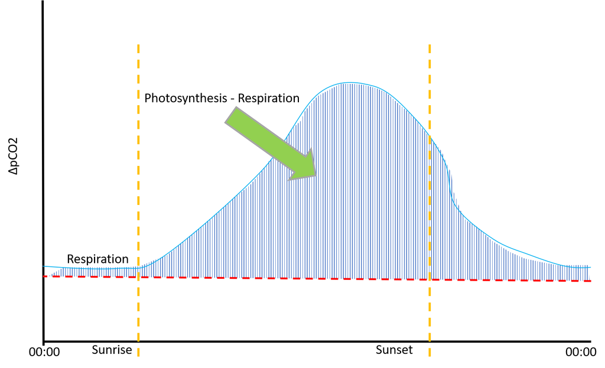

Metabolism

## Change in Dissolved Oxygen station 1 -> 4

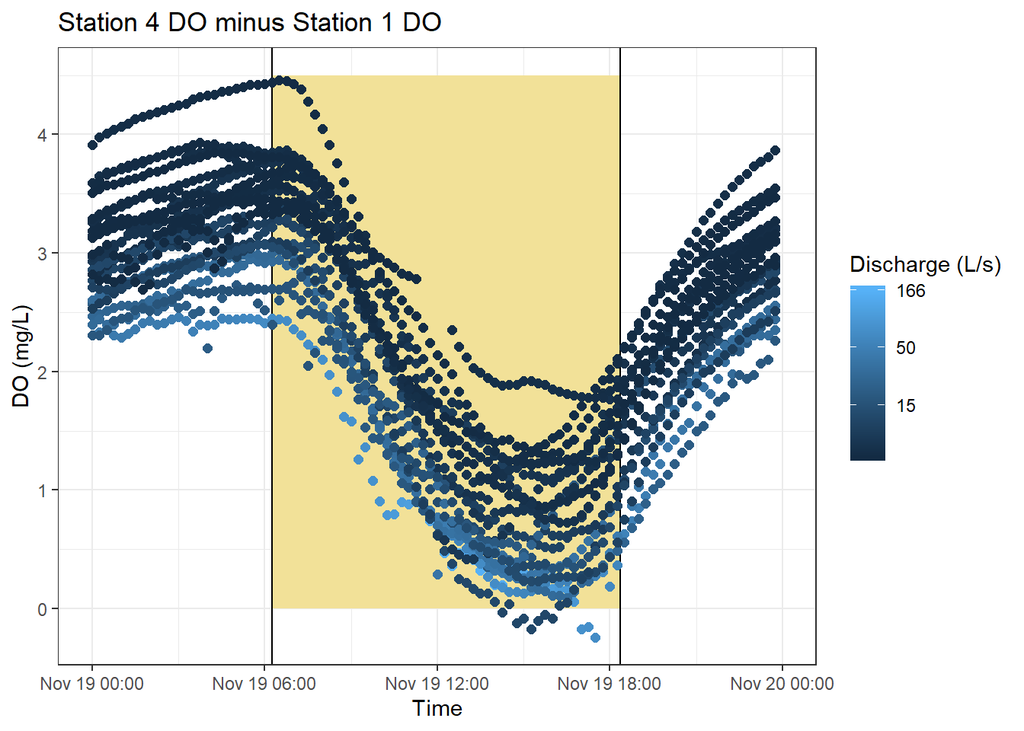

```r
dayPoly <- data.frame(x = c(as.POSIXct("06:15", format = "%H:%M"),as.POSIXct("18:21", format = "%H:%M"),as.POSIXct("18:21", format = "%H:%M"),as.POSIXct("06:15", format = "%H:%M")),y=c(0,0,4.5,4.5))

plot14DO <- ggplot(filt)+
  geom_polygon(data = dayPoly,aes(x=x,y=y),fill="#f2e198")+
  geom_vline(aes(xintercept = as.POSIXct("06:15", format = "%H:%M")))+
  geom_vline(aes(xintercept = as.POSIXct("18:21", format = "%H:%M")))+
  geom_point(aes(x = time, y = DO4_mg.L-DO1_mg.L,group = day, col=stn1_Q),lwd=2)+
  scale_color_gradient(name = "Discharge (L/s)", trans = "log",
                        breaks = my_breaks, labels = my_breaks)+
  labs(x = "Time",y="DO (mg/L)", title = "Station 4 DO minus Station 1 DO")+
  theme_bw()

plot14DO
```

## DO at each sensor

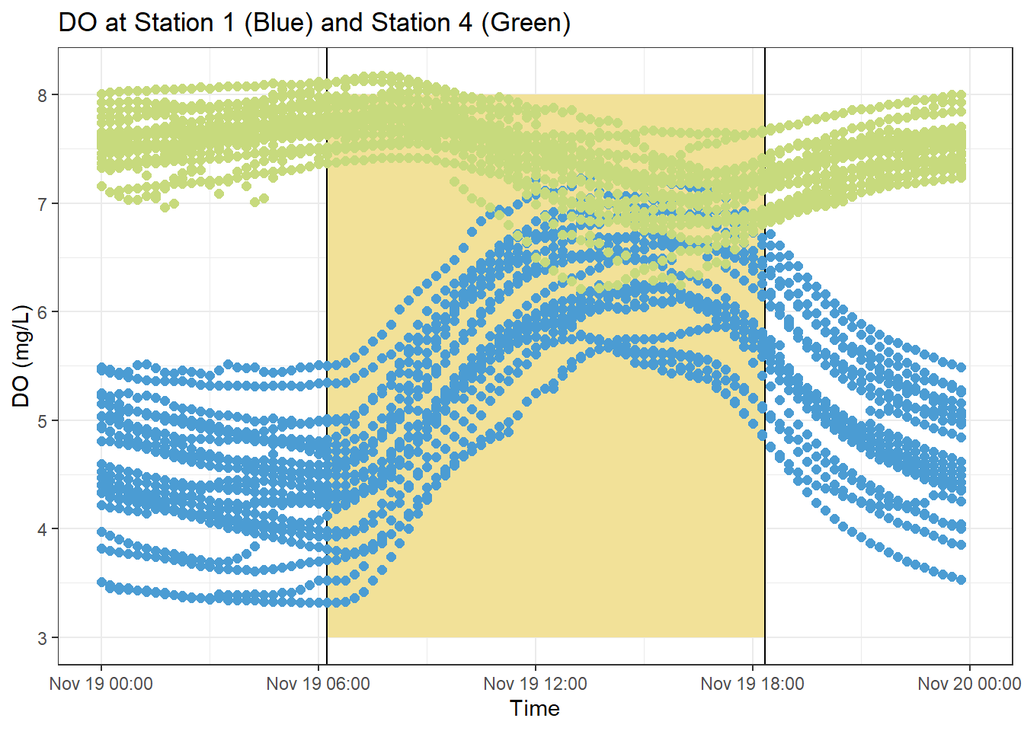

```r
dayPoly <- data.frame(x = c(as.POSIXct("06:15", format = "%H:%M"),as.POSIXct("18:21", format = "%H:%M"),as.POSIXct("18:21", format = "%H:%M"),as.POSIXct("06:15", format = "%H:%M")),y=c(3,3,8,8))

plotDO <- ggplot(filt)+
  geom_polygon(data = dayPoly,aes(x=x,y=y),fill="#f2e198")+
  geom_vline(aes(xintercept = as.POSIXct("06:15", format = "%H:%M")))+
  geom_vline(aes(xintercept = as.POSIXct("18:21", format = "%H:%M")))+
  geom_point(aes(x = time, y = DO1_mg.L,group = day),col = "#4B9CD3",lwd=2)+
  geom_point(aes(x = time, y = DO4_mg.L,group = day),col ="#C7DA7D",lwd=2)+
  scale_color_gradient(name = "Discharge (L/s)", trans = "log",
                        breaks = my_breaks, labels = my_breaks)+
  labs(x = "Time",y="DO (mg/L)", title = "DO at Station 1 (Blue) and Station 4 (Green)")+
  theme_bw()
plotDO
```

## Calculate respiration between stations 1 & 4

```r
filtsub <- filt%>%
  filter(time < as.POSIXct("06:30", format = "%H:%M"))%>%
  group_by(day)%>%
  mutate(baseDeltCo2 = max(V1-V4))%>%
  ungroup()%>%
  select(day,baseDeltCo2)%>%
  distinct()

filt <- left_join(filt,filtsub)%>%
  mutate(Uptake = baseDeltCo2-(V1-V4))
```

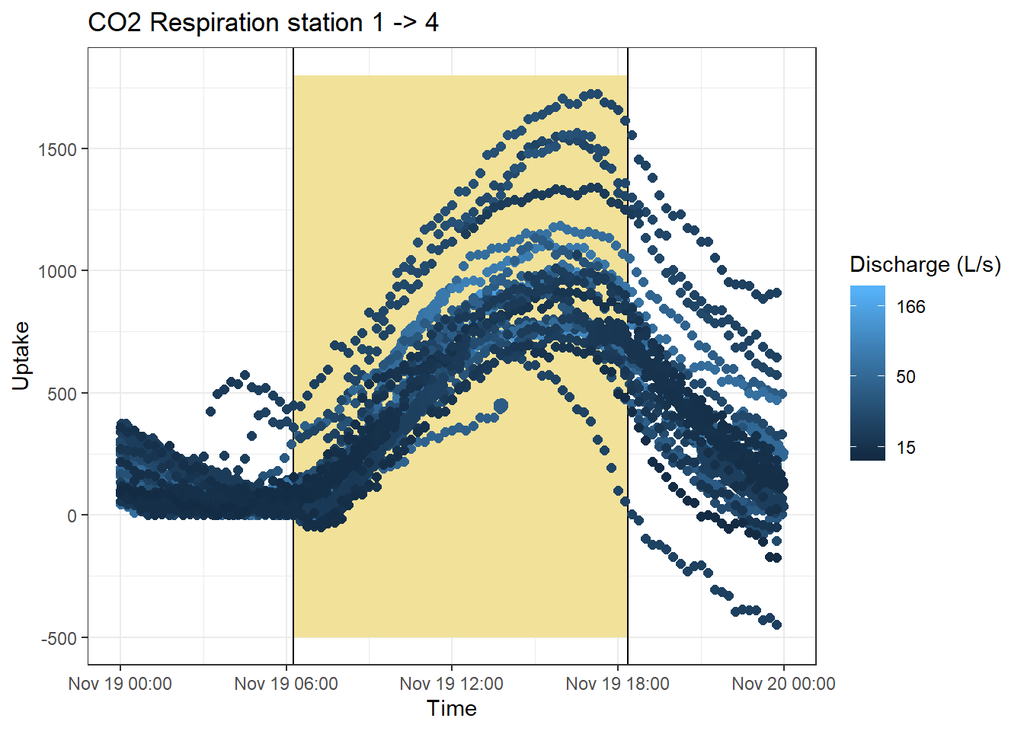

```r
dayPoly <- data.frame(x = c(as.POSIXct("06:15", format = "%H:%M"),as.POSIXct("18:21", format = "%H:%M"),as.POSIXct("18:21", format = "%H:%M"),as.POSIXct("06:15", format = "%H:%M")),y=c(-500,-500,1800,1800))

plotUptake <- ggplot(filt)+
  geom_polygon(data = dayPoly,aes(x=x,y=y),fill="#f2e198")+
  geom_vline(aes(xintercept = as.POSIXct("06:15", format = "%H:%M")))+
  geom_vline(aes(xintercept = as.POSIXct("18:21", format = "%H:%M")))+
  geom_point(aes(x = time, y = Uptake,group = day, col=stn3_Q),lwd=2)+
  scale_color_gradient(name = "Discharge (L/s)", trans = "log",
                        breaks = my_breaks, labels = my_breaks)+
  labs(x = "Time",y="Uptake", title = "CO2 Respiration station 1 -> 4")+
  theme_bw()
plotUptake
```

## Calculate Evasion using my equation

Now that we know the change in CO2 and uptake, we can calculate evasion.

```r
# Distances are 17,30,80

filt$evasion_14 <- ((filt$V1-(filt$V4+filt$Uptake))/ 100) *.0018*(1000000/44.01)*filt$stn3_Q/1000
```

## Plot data

### Histogram of Evasion Stations 1 -> 4

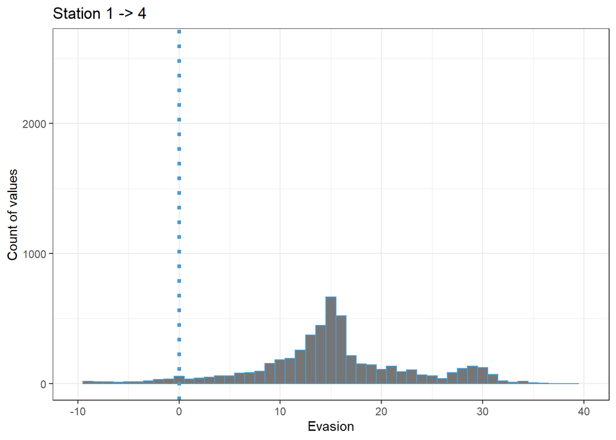

```r
ggplot(filt, warning = FALSE, message=FALSE)+
  geom_histogram(aes(x = evasion_14),fill = "#767676",color="#4B9CD3",binwidth = 1)+
  geom_vline(xintercept = 0, linetype="dotted", color = "#4B9CD3", size=1.5)+
  xlim(-10,40)+
  ylim(0,2600)+
  labs(x = "Evasion", y="Count of values",title = "Station 1 -> 4")+
  theme_bw()
```

## Evasion and time

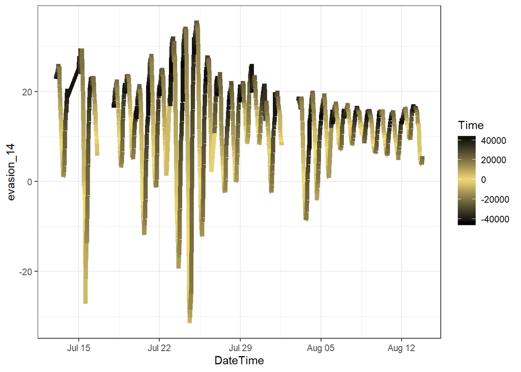

### ppt and Evasion

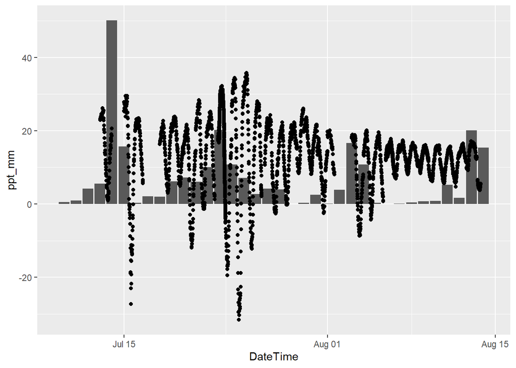

```r
pptBar <- ggplot()+
  geom_bar(data = pptDaily,stat = "identity", aes(x = DateTime, y = ppt_mm))+
  geom_point(data = filt,aes(x = DateTime, y = evasion_14))


pptBar
```

##Evasion

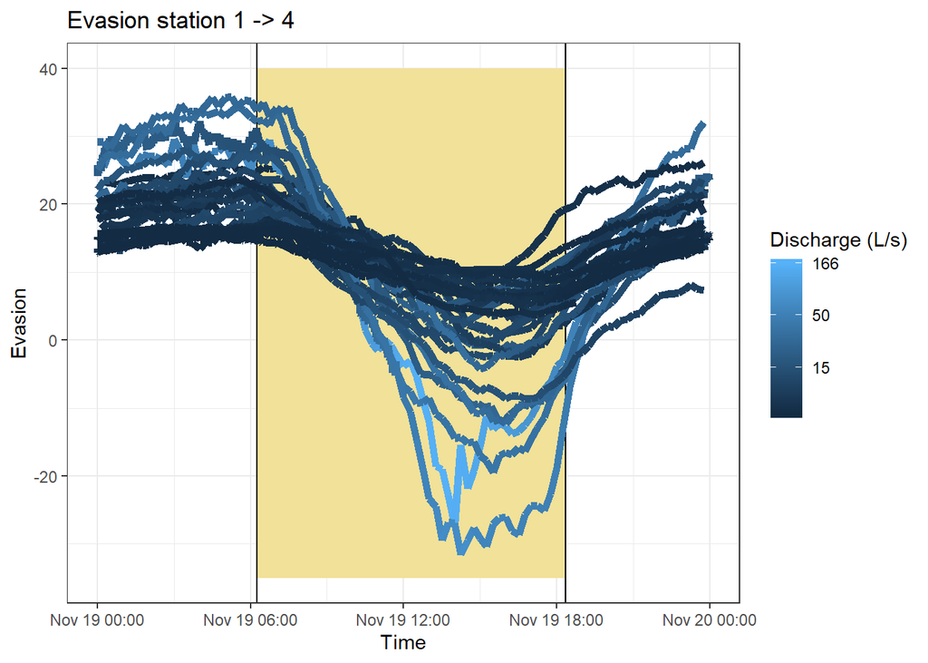

```r
dayPoly <- data.frame(x = c(as.POSIXct("06:15", format = "%H:%M"),as.POSIXct("18:21", format = "%H:%M"),as.POSIXct("18:21", format = "%H:%M"),as.POSIXct("06:15", format = "%H:%M")),y=c(-35,-35,40,40))

plot14 <- ggplot(filt)+
  geom_polygon(data = dayPoly,aes(x=x,y=y),fill="#f2e198")+
  geom_vline(aes(xintercept = as.POSIXct("06:15", format = "%H:%M")))+
  geom_vline(aes(xintercept = as.POSIXct("18:21", format = "%H:%M")))+
  geom_line(aes(x = time, y = evasion_14,group = day, col=stn1_Q),lwd=2)+
  scale_color_gradient(name = "Discharge (L/s)", trans = "log",
                        breaks = my_breaks, labels = my_breaks)+
  labs(x = "Time",y="Evasion", title = "Evasion station 1 -> 4")+
  theme_bw()

plot14
```

## Evasion vs. Evasion

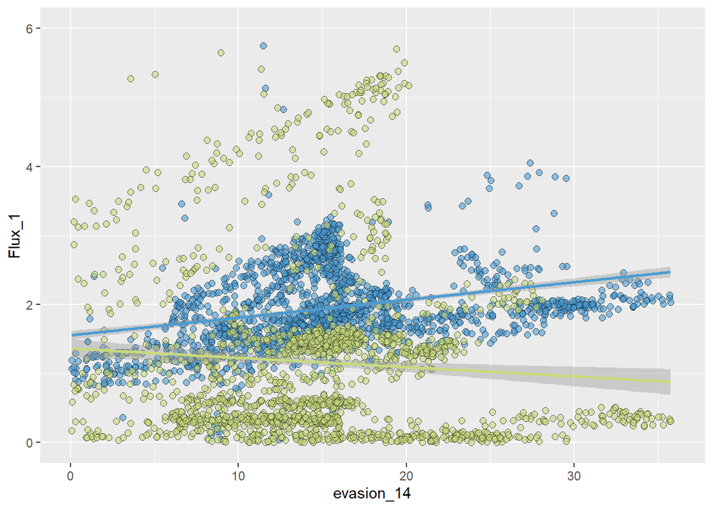

```r
ggplot(filt)+
  geom_point(shape=21,aes(x = evasion_14, y=Flux_1, fill = "eosFD 1"), fill="#4B9CD3", alpha =.6,size=2)+
  geom_point(shape=21,aes(x = evasion_14, y=Flux_2, fill = "eosFD 2"), fill="#C7DA7D", alpha = .6,size=2)+
  geom_smooth(aes(x=evasion_14,y=Flux_1),method='lm',formula=y~x, color = "#4B9CD3")+
  geom_smooth(aes(x=evasion_14,y=Flux_2),method='lm',formula=y~x,color ="#C7DA7D")+
  xlim(0,36)+
  ylim(0,6)
```